# 621-FinalProject

Ahmed Elsaeyed

2022-11-30

# Probability of Cardiovascular Disease

This research centers around building a model that predicts the probability of cardiovascular disease given some prior health information.

# Abstract

For our final assignment, we will be looking at a dataset of physical characteristics, behavioral characteristics, and health results of patients aged 30-59 in the 1940’s in the United States. The data was gathered by the Framingham Heart Study, which is a long-term ongoing study. 5209 subjects were monitored to see if cardiac health can be influenced by lifestyle and environmental factors. It is mainly due to studies like this one, and indeed this one in particular due to its large scope, that we take that conclusion for granted. Before this study, the contributing factors of cardiac health were not clear at all.

A result of this study is the 10-year cardiovascular risk score was developed, which is an estimation of how likely it is that someone will have a coronary disease based on the findings of the study. The objective of this project is to build a model to predict this to take their research a step further.

# Literature Review

Framingham Study is a study initiated by the United State Public Health Service, that started in 1948 and has been ongoing since. The origin of the study has been closely linked with the cardiovascular health of President Franklin D. Roosevelt and his death from hypertensive heart disease and stroke in 1945. It aims to investigate the epidemiology and factors that are involved in the development of cardiovascular disease. The plan of the study was to track a large cohort of patients over time. The study initially recruited the original cohort of 5209 participants from the town if Framingham, MA. The age group for this study ranges from 30-59 years old. The patients were given questionnaires and exams every 2 years and these questions and exams expanded with time. This study was continued over three generations of the original participants.

The data collected by the study was used to develop the Framingham Risk Score. The Framingham Risk Score is a sex-specific algorithm that is used to estimate the 10 year cardiovascular risk of an individual. This score gives an estimate probability of a person developing cardiovascular disease within a specified amount of time, the range of which can be from 10 to 30 years.

The study collect a range of 16 variables measurements from the patients in order to create the database. The variables include: Male, Age, Education, Current Smoker, Cigs Per Day, BP Medications, Prevalent Stroke, Prevalent Hypertension, Diabetes, Total Cholesterol, Systolic Blood Pressure, Diastolic Blood Pressure, Heart Rate, Glucose, CHD in 10 years. Most of the variable are categorized by their role is a person’s cardiovascular health.

Demographic Risk Factors: - Male - Age - Education

Behavioral Risk Factors: - Current Smoker - Cigs Per Day

Medical History Factors: - BP Medications - Prevalent Stroke - Prevalent Hypertension - Diabetes

Physical Exam Risk: - Total Cholesterol - Systolic Blood Pressure - Diastolic Blood Pressure - Heart Rate - Glucose

# Methodology

Our methodology for creating a predictive model for future coronary heart disease begins with cleaning and preprocessing our subject dataset. The dataset itself contains 16 fields, one of which is the target: `TenYearCHD`. While the dataset was relatively complete to begin with, we needed to employ multiple operations in order to transform it into a format which subsequent models could interpet. In this vain, we addressed missing values, multicollinearity, outliers, and mis-shaped data using a combination of self-developed functions and transformations. After cleaning / preprocessing, we split the new dataframe into training and testing sets in order to create and test various machine learning models. While developing models, we decided to try multiple approaches, including Binary Logistic Regression, standard and with log transforms, and Step-AIC. After each model, we calculated the relvant performance metrics and stored them in a tracker. Ultimately, our selection criteria was heavily influenced by the models’ recall and f1 scores. With medical diagnosis, it’s imperative that individuals with an illness be properly classified.

[output not shown]

# Experimentation and Results

```
[1] 4240   16
```

# Data Exploration

Our data set had 4,240 observations and 16 variables. `Sex`, `education`, `currentSmoker`, `BPMeds`, `prevalentStroke`, `prevalentHyp`, `diabetes` and `TenYearCHD` in the analysis carried out in this report are categorical variables, while the rest are numeric. The histograms for the numeric variables revealed that `BMI`, `glucose`, and `totChol` were skewed, and a Box-Cox transformation was undertaken for these variables in order to create new variables that contained the transformed versions of `BMI`, `glucose`, and `totChol`. An analysis into the correlation was done in order to remove variables that were highly correlated with another. Also, the data had several observations with missing data. The methodology that was undertaken to account for these missing values is shown in the “*Missing Values*” section. For comparison purposes, two different datasets were created; one containing the original data with observations with missing values omitted, and another containing manipulated data, where the data went through several transformations as explained in this report.

```
     Sex            age        education   currentSmoker   cigsPerDay
 female:2420   Min.   :32.00   1   :1720   No :2145      Min.   : 0.000
 male  :1820   1st Qu.:42.00   2   :1253   Yes:2095      1st Qu.: 0.000
               Median :49.00   3   : 689                 Median : 0.000
               Mean   :49.58   4   : 473                 Mean   : 9.006
               3rd Qu.:56.00   NA's: 105                 3rd Qu.:20.000
               Max.   :70.00                             Max.   :70.000
                                                         NA's   :29
  BPMeds     prevalentStroke prevalentHyp diabetes      totChol
 0   :4063   0:4215          0:2923       No :4131   Min.   :107.0
 1   : 124   1:  25          1:1317       Yes: 109   1st Qu.:206.0
 NA's:  53                                           Median :234.0
                                                     Mean   :236.7
                                                     3rd Qu.:263.0
                                                     Max.   :696.0
                                                     NA's   :50
     sysBP           diaBP            BMI          heartRate
 Min.   : 83.5   Min.   : 48.0   Min.   :15.54   Min.   : 44.00
 1st Qu.:117.0   1st Qu.: 75.0   1st Qu.:23.07   1st Qu.: 68.00
 Median :128.0   Median : 82.0   Median :25.40   Median : 75.00
 Mean   :132.4   Mean   : 82.9   Mean   :25.80   Mean   : 75.88
 3rd Qu.:144.0   3rd Qu.: 90.0   3rd Qu.:28.04   3rd Qu.: 83.00
 Max.   :295.0   Max.   :142.5   Max.   :56.80   Max.   :143.00
                                 NA's   :19      NA's   :1
    glucose       TenYearCHD
 Min.   : 40.00   0:3596
 1st Qu.: 71.00   1: 644
 Median : 78.00
 Mean   : 81.96
 3rd Qu.: 87.00
 Max.   :394.00
 NA's   :388
```

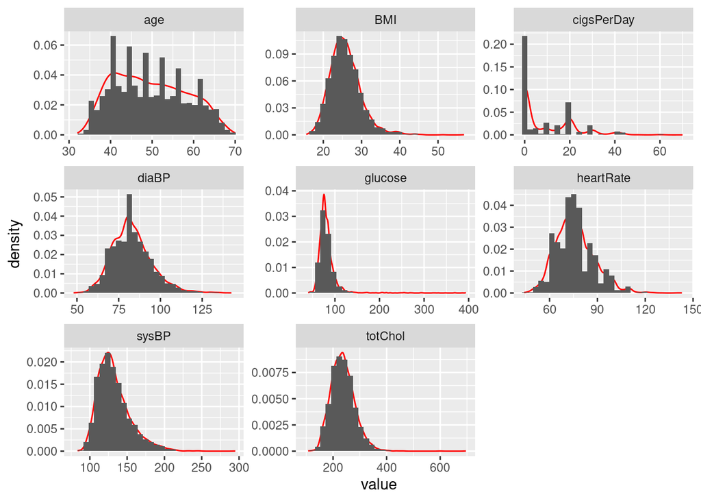

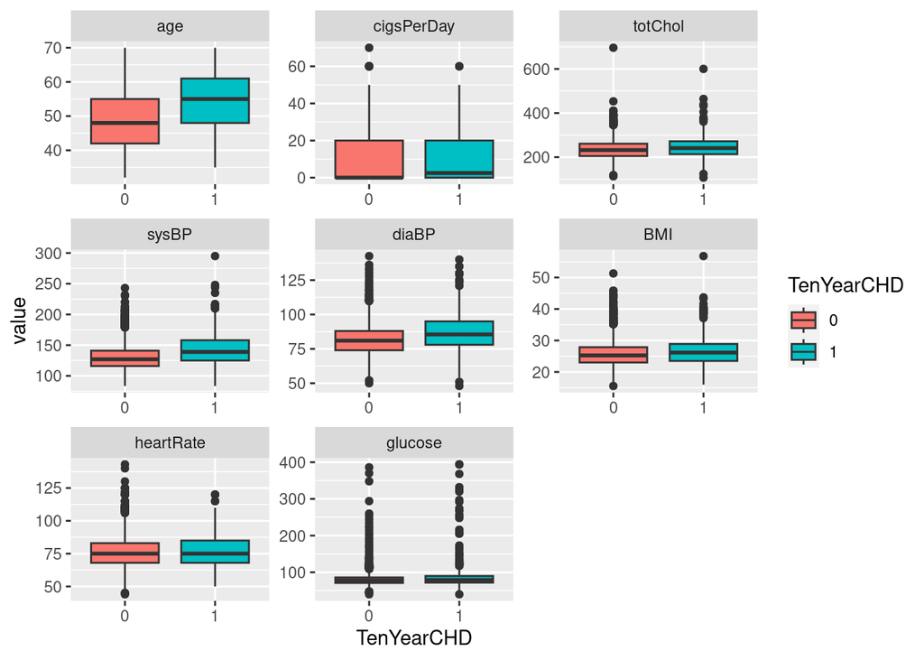

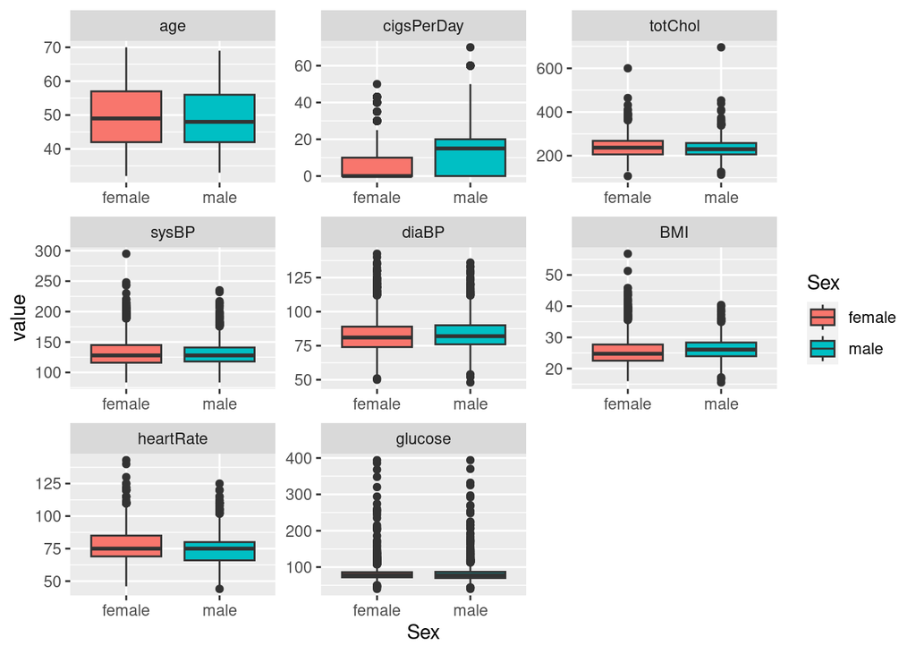

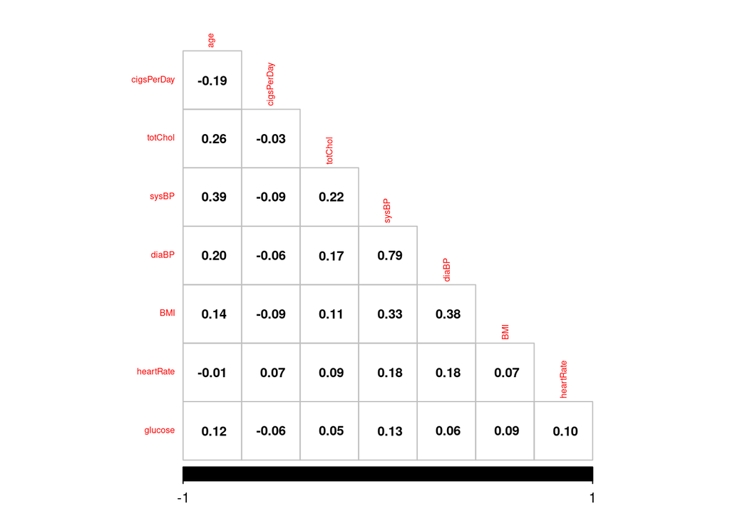

# Multicollinearity Analysis

Correlation refers to the strength of a relationship between two or more variables. Problems arise when there significant correlation between two or more predictor variables within a dataset, as this can lead to solutions that are wildly varying and possibly numerically unstable and there is redundancy between predictor variables. One solution to this is to drop one variable that is highly correlated with the other. Calkins explains that we can describe the correlation values between variables in the follwing manner:

- Correlation coefficients between 0.9 and 1 = very highly correlated
- Correlation coefficients between 0.7 and 0.9 = highly correlated
- Correlation coefficients between 0.5 and 0.7 = moderately correlated
- Correlation coefficients under 0.5 = low correlation

# Missing Values

| Variable Name | Percentage of Missing Data |
| --- | --- |
| education | 2.48 |
| cigsPerDay | 0.68 |
| BPMeds | 1.25 |
| totChol | 1.18 |
| BMI | 0.45 |
| heartRate | 0.02 |
| glucose | 9.15 |

*Table 2: Percentage of missing data for each of the variables that had missing data.*

Ultimately, it was decided to remove the observations with the missing values instead of imputing. The reason for this is explained in the “*Removing Outlier Values*” section.

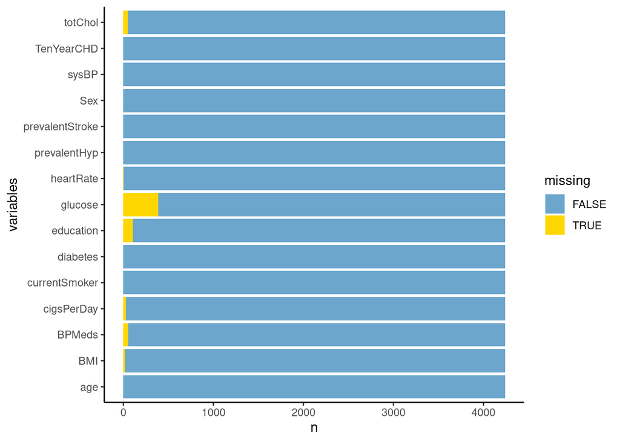

# Data Preparation

# Removing Outlier Values

The boxplots, summaries, and histograms that were generated revealed that some of these heart rates, diastolic, and systolic values as well as total cholesterol do not seem realistic. Imputing the values would not be appropriate because this is medical data and would harm the authenticity of the dataset, and so we have decided to simply remove the bad data.

We conducted research on suspected variables to further examine the authenticity of the data points in the dataset. Using multiple credited medical sources we created plausible ranges for each variable and omitted extreme or impossible values. Brief discussions and analysis of the process for each variable are below.

**Heart Rate**

An article by Cardiologist Jim Liu of Ohio State University states a normal resting heart rate, measured when the person is not exercising, is between 60 and 100 bpm (beats per minute). The further you move from 100 bpm increases the level of risk on the high sided. On the decreasing side going lower than 60 deviates from the safe levels. The risk levels are assigned by taking into account the heart rate along with the heart rhythm. Taking this into account we removed records with heart rates over a 100.

**Systolic Blood Pressure**

The FDA states that a normal blood pressure reading is 120/80 with 120 being the systolic measurement. If the systolic reading is 130, the blood pressure is considered high at Stage 1, and a reading of 140 is considered Stage 2. A systolic reading of 180 or greater is considered ‘hypertensive crisis’ and needs immediate medical attention. Taking into account the different stages of risk we declared a range of 100 to 160 an acceptable Systolic Blood Pressure reading.

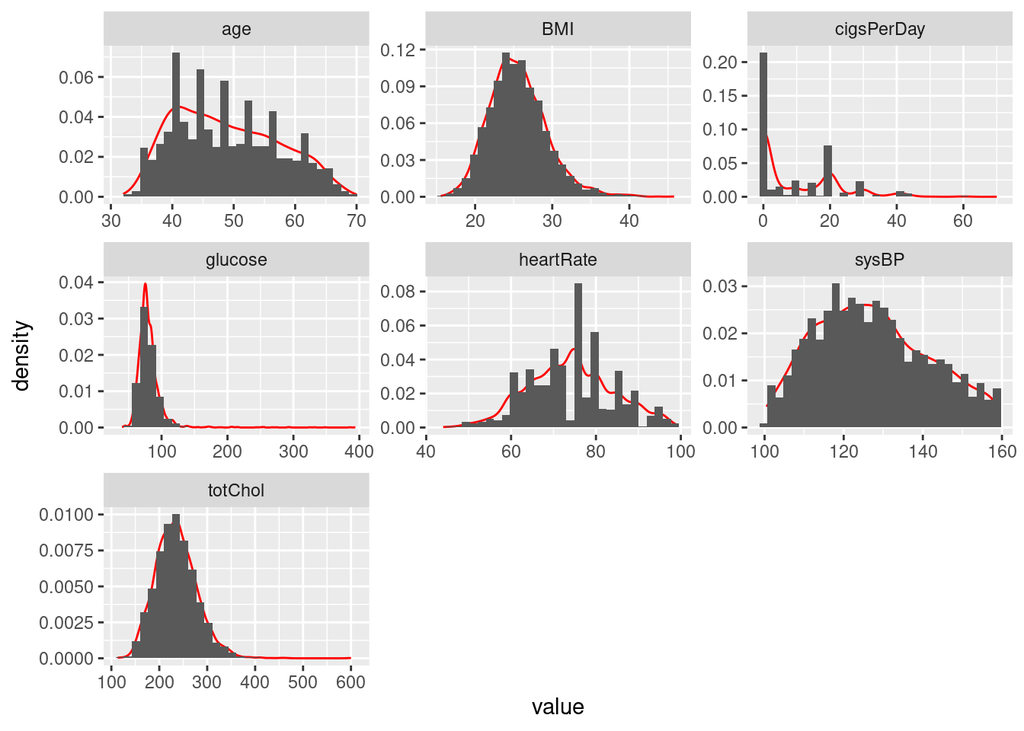

# Box-Cox Transformation for Skewed Variables

For the variables that exhibited skewness as explained in the “*Data Exploration*” section of this paper, A Modern Approach to Regression with R explains the following:

> …if the skewed predictor can be transformed to have a normal distribution conditional on Y, then just the transformed version of X should be included in the logistic regression model. (Sheather, 284)

The $\lambda$’s that were used to transform the skewed variables are shown on Table 3.

| Column Name | $\lambda$ |
| --- | --- |
| BMI | -0.309 |
| glucose | -1.279 |
| totChol | 0.069 |

*Table 3: $\lambda$’s for transforming skewed variables to normal distribution.*

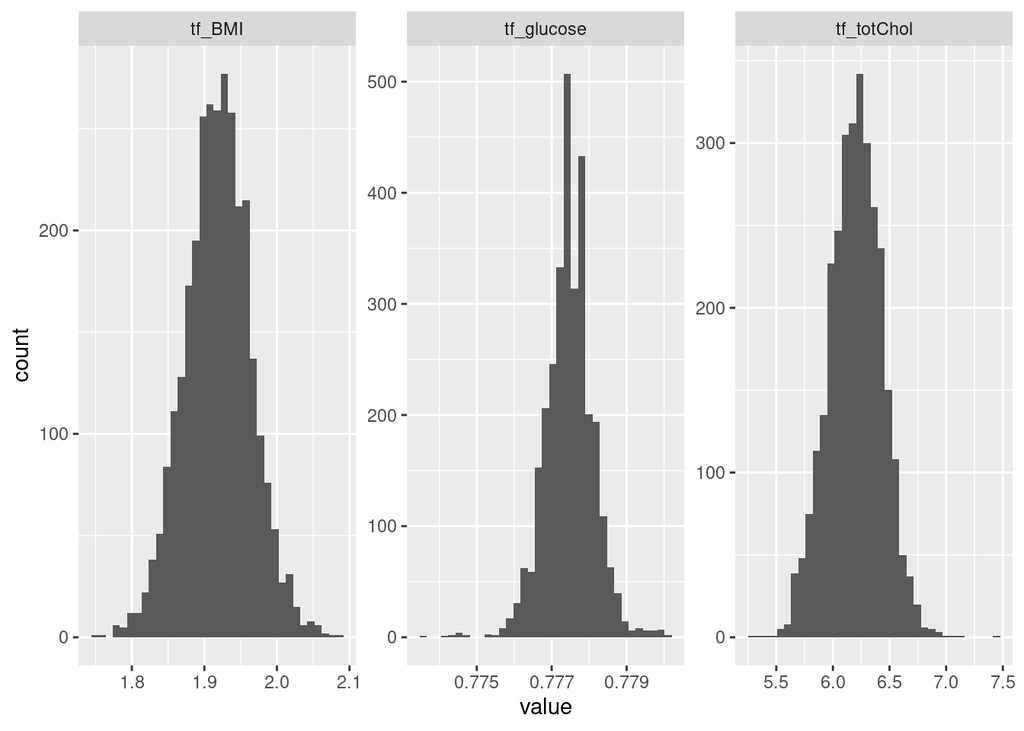

# Split Data Into Testing and Training

The data was into testing and training subsets such that 70% of it will be used to train, and 30% to test. The first row shows the split for the testing data while the second row shows the split for the training data. Tables 4 and 5 show the distributions of the testing and training data using the original and modified datasets.

[output not shown]

*Table 4: Distribution of testing and training data using original dataset*

[output not shown]

*Table 5: Distribution of testing and training data using modified/transformed dataset*

# Binary Logistic Regression Model with Original Data

A binary logistic regression model was generated using the original dataset. The observations with missing values were omitted. The final binary logistic regression takes on the following form:

$$\begin{aligned}
logit(p) = -9.155 + (0.504*Sex_{male}) + (0.066*age) + \\
(-0.290 * education_2) + (-0.223 * education_3) + (-0.120*education_4) +
\\
(0.086 * currentSmoker_{Yes}) + (0.019 * cigsPerDay) + (0.123 *
BPMeds_1) + \\
(0.982 * prevalentStroke_1) + (0.091 * prevalentHyp_1) + (-0.435 *
diabetes_{Yes}) + \\
(0.002 * totChol) + (0.018 *sysBP) + (-0.005 * diaBP) + (0.02 * BMI) +
\\
(-0.005 * heartRate) + (0.01 * glucose)
\end{aligned}$$
*Equation 1: Binary logistic regression model using original data.*

> People age 65 and older are much more likely than younger people to suffer a heart attack, to have a stroke, or to develop coronary heart disease (commonly called heart disease) and heart failure. Heart disease is also a major cause of disability, limiting the activity and eroding the quality of life of millions of older people. (NIH)

> Both low glucose level and impaired fasting glucose should be considered as predictors of risk for stroke and coronary heart disease. The fasting glucose level associated with the lowest cardiovascular risk may be in a narrow range. (Park)

This provides evidence as to probably why `glucose` is also statistically significant within the model.

```
Call:
glm(formula = TenYearCHD ~ ., family = binomial(link = "logit"),
    data = original_train)

Deviance Residuals:
    Min       1Q   Median       3Q      Max
-2.1920  -0.5860  -0.4192  -0.2732   2.7225

Coefficients:
                  Estimate Std. Error z value Pr(>|z|)
(Intercept)      -9.154885   0.877043 -10.438  < 2e-16 ***
Sexmale           0.503829   0.132129   3.813 0.000137 ***
age               0.066400   0.008136   8.161 3.32e-16 ***
education2       -0.290393   0.149348  -1.944 0.051846 .
education3       -0.223186   0.184932  -1.207 0.227486
education4       -0.119852   0.199401  -0.601 0.547800
currentSmokerYes  0.086271   0.189409   0.455 0.648768
cigsPerDay        0.018727   0.007488   2.501 0.012384 *
BPMeds1           0.123212   0.286340   0.430 0.666977
prevalentStroke1  0.982234   0.595212   1.650 0.098897 .
prevalentHyp1     0.090940   0.168521   0.540 0.589447
diabetesYes      -0.434817   0.409077  -1.063 0.287818
totChol           0.001996   0.001396   1.431 0.152566
sysBP             0.017671   0.004672   3.783 0.000155 ***
diaBP            -0.004660   0.007811  -0.597 0.550789
BMI               0.021327   0.015395   1.385 0.165957
heartRate        -0.004900   0.005042  -0.972 0.331105
glucose           0.011013   0.002930   3.759 0.000171 ***
---
Signif. codes:  0 '***' 0.001 '**' 0.01 '*' 0.05 '.' 0.1 ' ' 1

(Dispersion parameter for binomial family taken to be 1)

    Null deviance: 2185.3  on 2560  degrees of freedom
Residual deviance: 1903.2  on 2543  degrees of freedom
AIC: 1939.2

Number of Fisher Scoring iterations: 5
```